# 4. 随机变量及其函数

## 4.1 随机变量 RANDOM VARIABLE

### 4.1.1 定义R.V.

随机变量不是可变的量，而是一种映射关系，可以将其看做成一个函数，其传入的是Outcome，传出的是对应的数字。

注意：传出的必须是数字，比如：

1.

X(小明赢) = 0 X(小明输) = 1

正确

2.

X(x) = '六面出现点数x' x∈{1，2，3，4，5，6} 错误，不是随机变量，因为传出必须为数字

3.

X(六面出现点数x) = x， Y = X -3 ，对于X和Y来说，都是随机变量，因为其满足传出值为数字。

**用数学公式表示：随机变量$(r.v.)$指的是一种 $S → R$ 的映射，其中S为全集，R为实数。**

需要注意的是，将实验结果看作是基本元素，将事件看作由不同元素组成的小组，将S看作是元素清单，这有助于理解其三者关系。

R.V.的传入值是实验结果，所有的实验结果构成了 S 全集，而概率 P 传入的是事件，事件可以包含多个实验结果，是 S 的子集。

### 4.1.2 R.V.的类别

随机变量有两种不同的类别，其一为**离散随机变量(Discrete R.V.)**，其特点为集合元素可数，也就是说，映射对应的数字可数，比如：

对于所有的正整数集合，{1,2,3,...,n}，虽然它是一个无穷大集合，但是仍然被认为是可数的。

其二为**连续随机变量（Continuous R.V.）**，比如 X ∈ （0，1），这个显然是不可数的。

证明如下：对于任意0到1之间的数字，总能找到一个数字，其小数第一位等于9-第一个数字的第一位，其小数第二位等于9-第二个数字的第二位，...,使得此数字永远不能被数到。

0.1211..

0.2312..

0.3345..

..

构造数字为：

0.865.. 这个数字永远不可数

此外，还需要注意，对于无穷世界而言，正整数集合和正的偶数整数集合一样大，一条长度为1的线段的点和长度为1的正方形的点一样多，因为总能找到一一对应的关系，这里的技巧是**小数总有无限的位数/精度**

# 4.2 累积分布函数 CDF

CDF (Cumulaticve distribution function) 的定义是：$F_X(x) = P(X \le x)$

其中X表示随机变量（必须用大写），x表示此随机变量可能的取值，F表示CDF函数（通用）。

### 4.2.1 离散随机变量

对于离散随机变量而言，其CDF如下：

[figure not shown]

其中，$P(3 \le X \le 5)$ 的算法方法如下：

$P(3 \le X \le 5) = F_X(5) - F_X(3^-) = F_X(5) - F_X(3) + P(X=3)$

注意，此算法针对于离散随机变量而言。因为计算少算了在 X = 3 处的概率，因此要加上。

### 4.2.2 连续随机变量

对于连续随机变量而言，其CDF如下：

[figure not shown]

需要注意的是，没有以上的这种开合差异的区别，因为对于每个基本不可分的点，差异都是无穷小的。对于正态分布，如下：

```
Text(0,0.5,'Cumulaticve Probability')
```

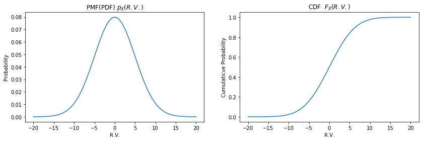

```python
from scipy.stats import norm
import matplotlib.pyplot as plt
import numpy as np
fig, axeses = plt.subplots(1,2)
fig.set_figwidth(14)
vx = np.linspace(-20,20,100)
vy = norm.pdf(vx,0,5)
vy_c = norm.cdf(vx,0,5)
axeses[0].plot(vx,vy)
axeses[0].set_title('PMF(PDF) $p_X(R.V.)$')
axeses[0].set_xlabel('R.V.')
axeses[0].set_ylabel('Probability')
axeses[1].plot(vx,vy_c)
axeses[1].set_title('CDF  $F_X(R.V.)$')
axeses[1].set_xlabel('R.V.')
axeses[1].set_ylabel('Cumulaticve Probability')
```

**不管是连续还是离散，对于CDF而言，其总满足：对于无穷小的R.V.，其值总是为0，对于无穷大的R.V.，其值总是为1。并且，值的范围总是在0到1之间。**

## 4.3 概率质量函数 PMF

PMF(Probability mass function)定义是： $p_X(x) = P(X = x)$

其中PMF和CDF的关系是： $F_X(x) = P(X \le x) = \sum_{n=-∞}^{x=[x]}P(X=n)$

每一个PMF都称作是一种概率分布（Probability Distribution），概率分布的意思是**随机变量X的总和为1的概率在各点的分布**。如上左图所示。

# 5. 离散随机分布

## 5.1 Bernoulli 分布

**1次实验，2种结果，关心是否发生某种结果**

$X ~ Bernoulli(p)$

[figure not shown]

## 5.2 Binomial 分布

**n次实验，1个概率，关心n次实验出现某种结果k次的概率**

$X- ~ BIN(n,p)$

[figure not shown]

## 5.3 Uniform 分布

**1次实验，n种结果，各种结果概率相等，关心某结果是否发生**

$X- ~ UNIF(a,b)$

[figure not shown]

## 5.4 Geometric 分布

**实验中出现某结果概率已知，重复操作一直到出现该结果为止，关系某结果在第几次实验才首次出现**

$X- ~ Geometric(p)$

几何概率有失忆性，可以由PMF看出，当第二次尝试的时候，概率逐渐降低，因为发生第二次尝试需要条件（只要成功一次即可）。

[figure not shown]

## 5.5 Pascal 分布

**实验中出现结果概率已知，重复操作实验到该结果出现第k次为止，关心在第几次实验才结束**

$X- ~ Pascal(k,p)$

[figure not shown]

**由于Pascal分布的CDF很像BIN二项分布的反向，所有Pascal分布又被称之为Negative Binomial分布。**

## 5.6 Poisson 分布

**已知结果出现的平均速率 𝝀 ，问观察某段时间 T 长度后，看到结果出现 X 次的概率？**

$X- ~ POI(𝝀,T) \quad OR \quad X- ~ POI(μ)，μ=𝝀·T$

[figure not shown]

需要注意，Poisson分布可以由以下方式得到：

其中，将时间T分割为小段，然后每一段发生的可能性只有两种，发生或者不发生，所以可以看作是长度为 n 的，概率为 p 的 BIN 分布，证明如下：

[figure not shown]

### 5.6.1 泊松分布很有意思的一个问题

https://blog.csdn.net/zhaoxinfan/article/details/12390173

```python
# -*- coding: utf-8 -*-

from math import *
from random import random

### 一次测试 ###
def test():
    speed = 4.0                #初速度
    distance = 0               #已经走过的距离
    threshold = log(50) / 100  #每秒中枪的概率

    while distance < 400:
        distance += speed        #以当前速度移动

        if random() < threshold: #如果中枪，则判断是否死亡，如果不死亡，速度减半
            if speed == 0.5:
                return 0             #死亡！
            else:
                speed /= 2

    return 1                   #成功通过！

### 模拟 ###
succ = 0.0                   #成功次数
times = 100000               #模拟次数，可随需要更改，越大则越准确，但耗时越多
for i in range(0, times):
    if test() == 1:
        succ += 1

print(succ,times)
print(round(succ / times, 10))
#成功频率，以此作为概率估算值，结果保留两位小数-0.06
```

```
5795.0 100000
0.05795
```

更新日志：

2018年5月21日 SP0.9-180521